# Do Homebuyers Care About Good Grades?: Evaluating the Effect of NYC School Accountability Program on Housing Values

John Ihor Campagna

December 3, 2017

## I. Introduction

- 2006-2007 First year of NYC Progress Reports implemented
- Followed NCLB and state programs in TX,FL,NC
- Goals were to pressure schools to reform and improve student outcomes
- Accountability programs created a unique discontiuity to study
- Consequences broader than student outcomes
- NYC large urban, and multiple ethnic context to explore the consequences

## II Background | School Accountability Literature

Student Outcomes

- Rockoff and Turner(2010) NYC positive effect D/F first year
- Cowen and Winters(2011) NYC positive effect persists
- Elena Rouse and Figlio (2006) Florida positive effect

Labor and Demographic

- Deming et al. (2016) Income and college effects
- Dizon-Ross (2017) Teacher Responses NYC
- Hart and Figlio (2015) Demographic Shifts

## II. Background | School Quality Literature

How Much Does School Quality Matter?

- Black (1999) BDD design
- Bayer, Ferreira and McMillan (2007) Sorting along border

What Matters?

- Clapp, Nanda and Ross (2008) Race matters
- Brassington and Haurin (2006) Value added measures don’t
- Horn, Schwartz, and Voicu (2014) School Choice matters

## II Background | School Quality and Accountability

Do Accountability Assesments Matter?

- Figlio and Lucas (2004) Yes, FL for high grades
- Kane et al.(2002) no in NC
- Martinez (2010) yes in NC

## III. Data | NYC DOE

- Number of schools vary slightly by year

## III. Data | NYC DOE

[output not shown]

-In Practice with additonal credit these are not the actual percentiles. -After 08-09 Scores percentiles implemneted before that cut scores were used

## III. Data | NYC DOE

- Test Score Data
- NY State ELA and Math exams for grades 3-8
- School Zones
- Can vary slightly by year, but only increase
- Most, but not all zones, have one school associated with it
- School Demographic

## IV. Summary Stats: Properties in School Zones

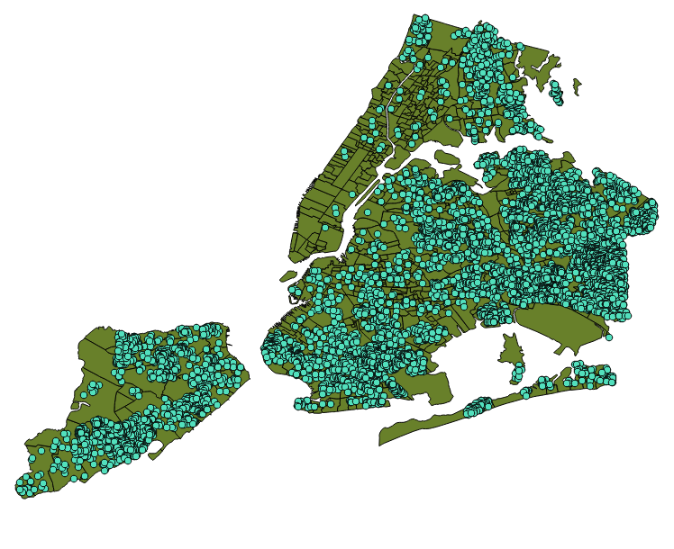

Properties in School Zones

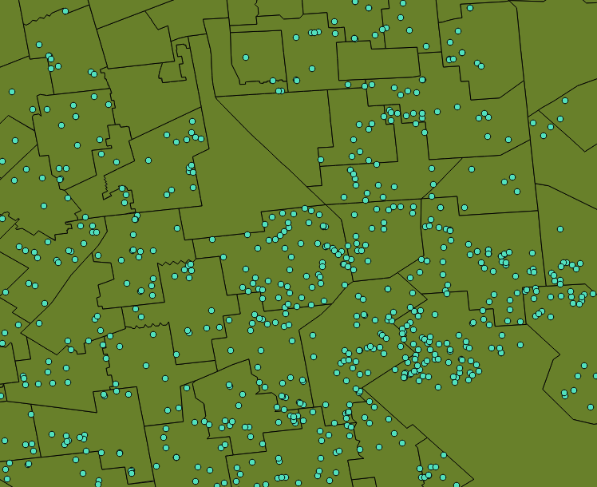

Properties in School ZOnes Brooklyn

## IV. Summary Stats: Borough Characteristics

**Manhattan School Descriptive Statistics**

| Statistic | N | Mean | St. Dev. | Min | Max |
| --- | --- | --- | --- | --- | --- |
| English Test Score | 22 | 662 | 9 | 652 | 683 |
| Math Test Score | 22 | 681 | 14 | 657 | 711 |
| English Language Learners Percent | 22 | 22 | 15 | 5 | 50 |
| Special Education Percent | 22 | 16 | 4 | 7 | 23 |
| Asian Percent | 22 | 4 | 6 | 0 | 20 |
| Black Percent | 22 | 29 | 28 | 0 | 80 |
| Hispanic Percent | 22 | 53 | 29 | 17 | 94 |
| White Percent | 22 | 11 | 18 | 0 | 60 |
| Sale Price | 22 | 1,366,514 | 976,840 | 150,000 | 2,925,000 |
| Note: The mean and SD are rounded |  |  |  |  |  |

**Brooklyn School Descriptive Statistics**

| Statistic | N | Mean | St. Dev. | Min | Max |
| --- | --- | --- | --- | --- | --- |
| English Test Score | 1,489 | 669 | 7 | 651 | 689 |
| Math Test Score | 1,489 | 690 | 11 | 663 | 715 |
| English Language Learners Percent | 1,489 | 13 | 9 | 1 | 63 |
| Special Education Percent | 1,489 | 14 | 4 | 5 | 39 |
| Asian Percent | 1,489 | 15 | 16 | 0 | 90 |
| Black Percent | 1,489 | 34 | 33 | 0 | 96 |
| Hispanic Percent | 1,489 | 20 | 15 | 1 | 95 |
| White Percent | 1,489 | 30 | 25 | 0 | 93 |
| Sale Price | 1,489 | 560,999 | 388,834 | 5,000 | 2,950,000 |
| Note: The mean and SD are rounded |  |  |  |  |  |

**Queens School Descriptive Statistics**

| Statistic | N | Mean | St. Dev. | Min | Max |
| --- | --- | --- | --- | --- | --- |
| English Test Score | 4,204 | 670 | 8 | 650 | 694 |
| Math Test Score | 4,204 | 692 | 14 | 667 | 724 |
| English Language Learners Percent | 4,204 | 10 | 8 | 1 | 61 |
| Special Education Percent | 4,204 | 13 | 4 | 5 | 31 |
| Asian Percent | 4,204 | 29 | 24 | 0 | 80 |
| Black Percent | 4,204 | 29 | 36 | 0 | 95 |
| Hispanic Percent | 4,204 | 22 | 17 | 3 | 96 |
| White Percent | 4,204 | 19 | 21 | 0 | 90 |
| Sale Price | 4,204 | 453,233 | 240,901 | 2,500 | 2,600,000 |
| Note: The mean and SD are rounded |  |  |  |  |  |

| Statistic | N | Mean | St. Dev. | Min | Max |
| --- | --- | --- | --- | --- | --- |
| English Test Score | 533 | 663 | 6 | 650 | 677 |
| Math Test Score | 533 | 682 | 7 | 662 | 699 |
| English Language Learners Percent | 533 | 8 | 6 | 1 | 34 |
| Special Education Percent | 533 | 16 | 4 | 10 | 34 |
| Asian Percent | 533 | 6 | 5 | 0 | 31 |
| Black Percent | 533 | 30 | 25 | 0 | 81 |
| Hispanic Percent | 533 | 46 | 17 | 15 | 86 |
| White Percent | 533 | 18 | 19 | 0 | 69 |
| Sale Price | 533 | 376,996 | 279,349 | 4,000 | 2,800,000 |
| Note: The mean and SD are rounded |  |  |  |  |  |

**Staten Island School Descriptive Statistics**

| Statistic | N | Mean | St. Dev. | Min | Max |
| --- | --- | --- | --- | --- | --- |
| English Test Score | 1,163 | 670 | 7 | 648 | 681 |
| Math Test Score | 1,163 | 693 | 9 | 667 | 707 |
| English Language Learners Percent | 1,163 | 6 | 5 | 0 | 38 |
| Special Education Percent | 1,163 | 19 | 4 | 12 | 28 |
| Asian Percent | 1,163 | 7 | 5 | 0 | 36 |
| Black Percent | 1,163 | 9 | 14 | 0 | 55 |
| Hispanic Percent | 1,163 | 20 | 13 | 6 | 73 |
| White Percent | 1,163 | 63 | 26 | 8 | 89 |
| Sale Price | 1,163 | 395,788 | 181,858 | 1,756 | 2,450,000 |
| Note: The mean and SD are rounded |  |  |  |  |  |